# Enflasyon Oranı

2024-05-26

** Verinin okutulması **

```r
getwd()
```

```
## [1] "C:/Users/Asus/Documents/r data"
```

```r
data <- read.xlsx("EVDS (1).xlsx", sheetName="EVDS")
```

```r
sapply(data, class)
```

```
##                      Tarih      Uretim.Endeksi.kisi..
##                  "numeric"                  "numeric"
## Uretim.Endeksi.Mev..kisi..                      Altin
##                  "numeric"                  "numeric"
##              Konut.Endeksi                  Gyih.bin.
##                  "numeric"                  "numeric"
##                 Im.Kap.Kul              Issizlik.Oran
##                  "numeric"                  "numeric"
##              Istihdam.Oran                  Nufus.15.
##                  "numeric"                  "numeric"
##                    Is.Gucu              Istihdam.Say.
##                  "numeric"                  "numeric"
##                Issziz.Say.           Calismayan.Nufus
##                  "numeric"                  "numeric"
##            Is.Gucu.Kat.Or.                       TUFE
##                  "numeric"                  "numeric"
##                        UFE
##                  "numeric"
```

```r
# Eksik veri kontrolü
colSums(is.na(data))
```

```
##                      Tarih      Uretim.Endeksi.kisi..
##                          0                          0
## Uretim.Endeksi.Mev..kisi..                      Altin
##                          0                          0
##              Konut.Endeksi                  Gyih.bin.
##                          0                          0
##                 Im.Kap.Kul              Issizlik.Oran
##                          0                          0
##              Istihdam.Oran                  Nufus.15.
##                          0                          0
##                    Is.Gucu              Istihdam.Say.
##                          0                          0
##                Issziz.Say.           Calismayan.Nufus
##                          0                          0
##            Is.Gucu.Kat.Or.                       TUFE
##                          0                          0
##                        UFE
##                          0
```

```r
library(knitr)
```

```r
#verinin gösterimi
kable(data, format = "markdown",  row.names = TRUE, caption = "Data")
```

Data

|  | Tarih | Uretim.Endeksi.kisi.. | Uretim.Endeksi.Mev..kisi.. | Altin | Konut.Endeksi | Gyih.bin. | Im.Kap.Kul | Issizlik.Oran | Istihdam.Oran | Nufus.15. | Is.Gucu | Istihdam.Say. | Issziz.Say. | Calismayan.Nufus | Is.Gucu.Kat.Or. | TUFE | UFE |
| --- | --- | --- | --- | --- | --- | --- | --- | --- | --- | --- | --- | --- | --- | --- | --- | --- | --- |
| 1 | 2014 | 96.4950 | 95.6200 | 594.7333 | 73.1 | 2054897828 | 75.01667 | 9.883333 | 45.24167 | 56984.83 | 28605.17 | 25774.33 | 2830.917 | 28379.50 | 50.20833 | 242.0200 | 234.7833 |
| 2 | 2015 | 100.0075 | 100.0075 | 672.7208 | 84.5 | 2350941343 | 76.82500 | 10.333333 | 45.79167 | 57869.58 | 29549.83 | 26501.25 | 3048.750 | 28319.42 | 51.05833 | 260.5850 | 247.1867 |
| 3 | 2016 | 103.3200 | 104.5450 | 806.8958 | 94.8 | 2626559710 | 77.35833 | 10.908333 | 46.17500 | 58739.08 | 30449.67 | 27125.92 | 3323.500 | 28289.50 | 51.84167 | 280.8458 | 257.8108 |
| 4 | 2017 | 109.7075 | 110.8675 | 991.1167 | 103.4 | 3133704267 | 78.48333 | 10.925000 | 46.88333 | 59892.75 | 31515.50 | 28074.58 | 3441.000 | 28377.25 | 52.60833 | 312.1442 | 298.6033 |
| 5 | 2018 | 109.1525 | 113.5875 | 1359.8625 | 108.0 | 3761165557 | 76.83333 | 10.891667 | 47.30000 | 60653.50 | 32203.50 | 28690.92 | 3512.500 | 28450.08 | 53.09167 | 363.1250 | 379.2533 |
| 6 | 2019 | 109.9450 | 116.1325 | 1760.8925 | 118.8 | 4317809824 | 75.90000 | 13.741667 | 45.62500 | 61467.83 | 32505.58 | 28042.42 | 4463.083 | 28962.25 | 52.89167 | 418.2358 | 445.8625 |
| 7 | 2020 | 106.8475 | 125.4675 | 2790.2317 | 154.9 | 5048567945 | 71.86667 | 13.141667 | 42.65000 | 62576.75 | 30724.33 | 26684.75 | 4039.667 | 31852.33 | 49.09167 | 469.5908 | 500.1692 |
| 8 | 2021 | 113.3975 | 124.6525 | 3527.1708 | 247.4 | 7256141737 | 76.62500 | 12.033333 | 45.20833 | 63703.00 | 32732.17 | 28805.58 | 3926.583 | 30970.75 | 51.37500 | 561.6142 | 719.5325 |
| 9 | 2022 | 112.8525 | 123.0225 | 6604.0192 | 662.7 | 15011775979 | 77.20833 | 10.483333 | 47.50000 | 64677.58 | 34316.25 | 30724.50 | 3591.667 | 30361.42 | 53.05000 | 967.7108 | 1643.9425 |
| 10 | 2023 | 112.7375 | 123.4900 | 10640.7833 | 1163.3 | 26276307373 | 76.30000 | 9.391667 | 48.39167 | 65423.75 | 34931.58 | 31653.58 | 3277.833 | 30492.33 | 53.40833 | 1488.9142 | 2464.7508 |

```r
#merkezi dağılım tablosunu oluşturulması
func<-c("min","max","mean","median", "var","sd","skewness","kurtosis")
desc<-matrix(nrow=17,ncol=8)
colnames(desc) <-func
rownames(desc) <-colnames(data)
for(i in 1:length(func)) desc[,i]<-round(sapply(data[,0:17], FUN=func[i]),digits = 2)
desc_formatted <- apply(desc, 2, function(x) sprintf("%.2f", x))

rownames(desc_formatted) <- rownames(desc)
colnames(desc_formatted) <- colnames(desc)
# Tabloyu oluşturma ve gösterme
kable(desc_formatted, format = "markdown", col.names = func, row.names = TRUE, caption = "Descriptive Statistics")
```

Descriptive Statistics

|  | min | max | mean | median | var | sd | skewness | kurtosis |
| --- | --- | --- | --- | --- | --- | --- | --- | --- |
| Tarih | 2014.00 | 2023.00 | 2018.50 | 2018.50 | 9.17 | 3.03 | 0.00 | -1.56 |
| Uretim.Endeksi.kisi.. | 96.50 | 113.40 | 107.45 | 109.43 | 33.28 | 5.77 | -0.65 | -1.13 |
| Uretim.Endeksi.Mev..kisi.. | 95.62 | 125.47 | 113.74 | 114.86 | 117.03 | 10.82 | -0.37 | -1.54 |
| Altin | 594.73 | 10640.78 | 2974.84 | 1560.38 | 10662044.40 | 3265.28 | 1.29 | 0.28 |
| Konut.Endeksi | 73.10 | 1163.30 | 281.09 | 113.40 | 127273.66 | 356.75 | 1.55 | 0.92 |
| Gyih.bin. | 2054897827.65 | 26276307372.89 | 7183787156.27 | 4039487690.60 | 59680855108151468032.00 | 7725338510.91 | 1.51 | 0.90 |
| Im.Kap.Kul | 71.87 | 78.48 | 76.24 | 76.72 | 3.20 | 1.79 | -1.25 | 0.87 |
| Issizlik.Oran | 9.39 | 13.74 | 11.17 | 10.90 | 1.94 | 1.39 | 0.61 | -1.07 |
| Istihdam.Oran | 42.65 | 48.39 | 46.08 | 45.98 | 2.56 | 1.60 | -0.59 | -0.33 |
| Nufus.15. | 56984.83 | 65423.75 | 61198.87 | 61060.67 | 8343200.24 | 2888.46 | 0.03 | -1.58 |
| Is.Gucu | 28605.17 | 34931.58 | 31753.36 | 31859.50 | 3997530.86 | 1999.38 | 0.06 | -1.30 |
| Istihdam.Say. | 25774.33 | 31653.58 | 28207.78 | 28058.50 | 3463030.27 | 1860.92 | 0.51 | -1.07 |
| Issziz.Say. | 2830.92 | 4463.08 | 3545.55 | 3476.75 | 235982.70 | 485.78 | 0.37 | -0.99 |
| Calismayan.Nufus | 28289.50 | 31852.33 | 29445.48 | 28706.17 | 1795588.47 | 1340.00 | 0.54 | -1.51 |
| Is.Gucu.Kat.Or. | 49.09 | 53.41 | 51.86 | 52.22 | 2.02 | 1.42 | -0.61 | -1.09 |
| TUFE | 242.02 | 1488.91 | 536.48 | 390.68 | 157858.95 | 397.31 | 1.38 | 0.53 |
| UFE | 234.78 | 2464.75 | 719.19 | 412.56 | 554176.20 | 744.43 | 1.37 | 0.33 |

**Değişim aralığı (Range)**

```r
# Tüm sütunlar için aralıkları hesapla
araliklar <- sapply(data, function(x) diff(range(x)))
# data çerçevesi oluştur
aralik_df <- data.frame(de = names(araliklar), Aralik = araliklar)
# Aralık değerlerini formatla
aralik_df$Aralik <- sprintf("%.2f", aralik_df$Aralik)

# Tabloyu oluşturma ve gösterme
kable(aralik_df, format = "markdown", col.names = c("Değişken", "Aralık"), row.names = FALSE, caption = "Değişkenlerin Aralık Değerleri")
```

Değişkenlerin Aralık Değerleri

| Değişken | Aralık |
| --- | --- |
| Tarih | 9.00 |
| Uretim.Endeksi.kisi.. | 16.90 |
| Uretim.Endeksi.Mev..kisi.. | 29.85 |
| Altin | 10046.05 |
| Konut.Endeksi | 1090.20 |
| Gyih.bin. | 24221409545.24 |
| Im.Kap.Kul | 6.62 |
| Issizlik.Oran | 4.35 |
| Istihdam.Oran | 5.74 |
| Nufus.15. | 8438.92 |
| Is.Gucu | 6326.42 |
| Istihdam.Say. | 5879.25 |
| Issziz.Say. | 1632.17 |
| Calismayan.Nufus | 3562.83 |
| Is.Gucu.Kat.Or. | 4.32 |
| TUFE | 1246.89 |
| UFE | 2229.97 |

# Kutu Grafikleri

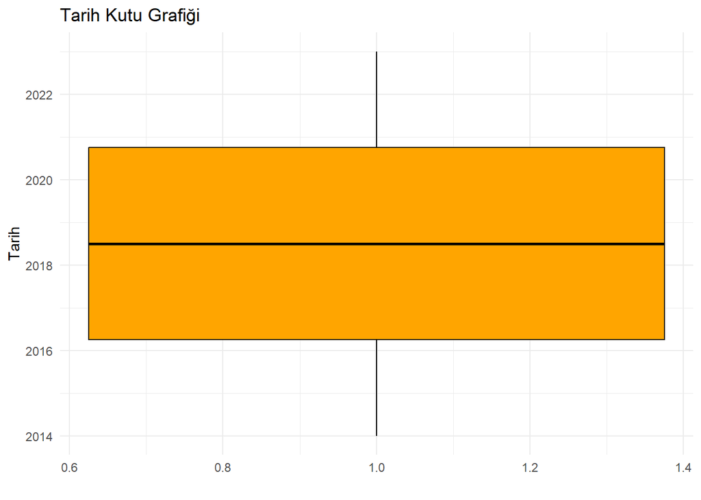

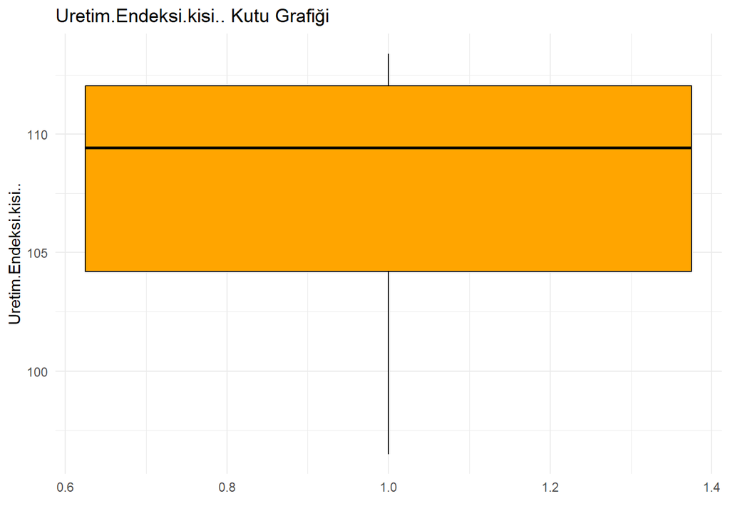

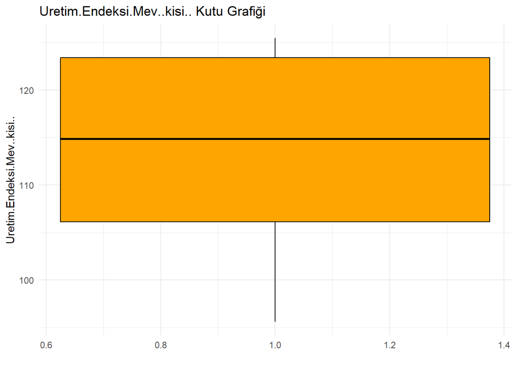

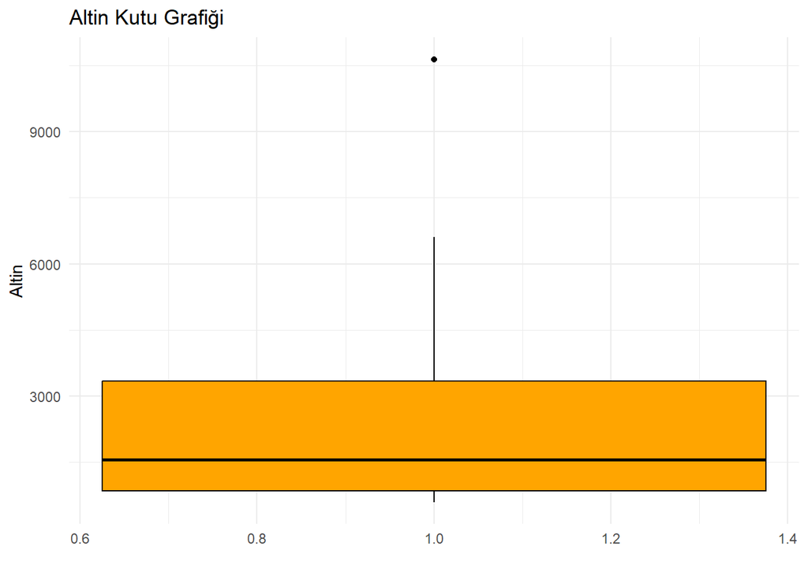

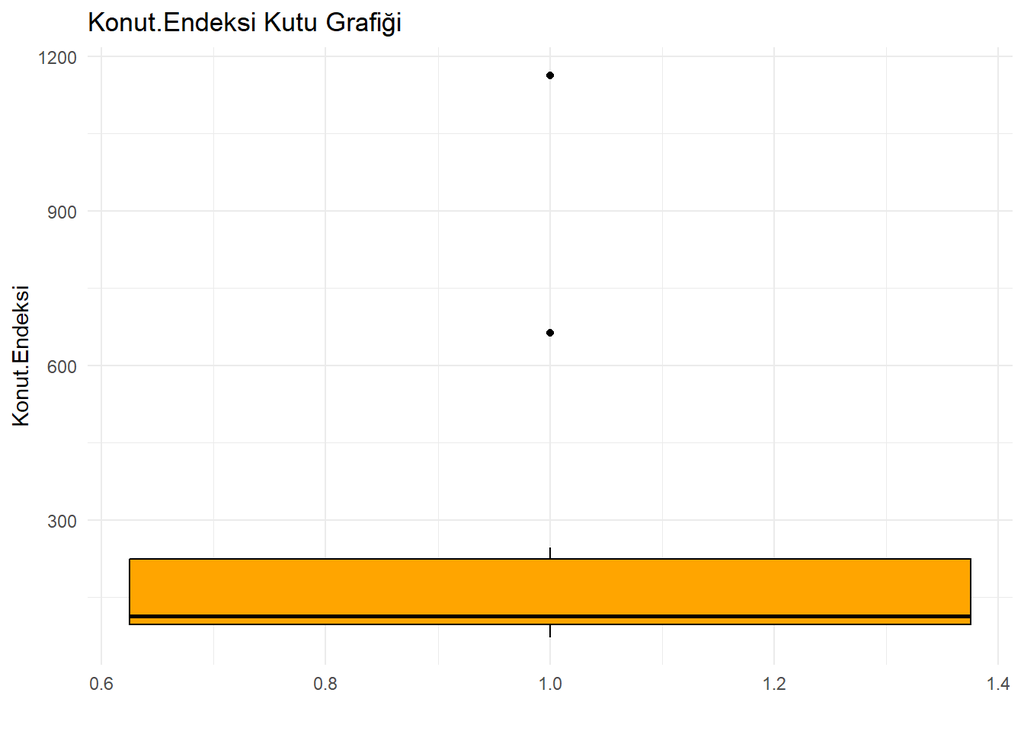

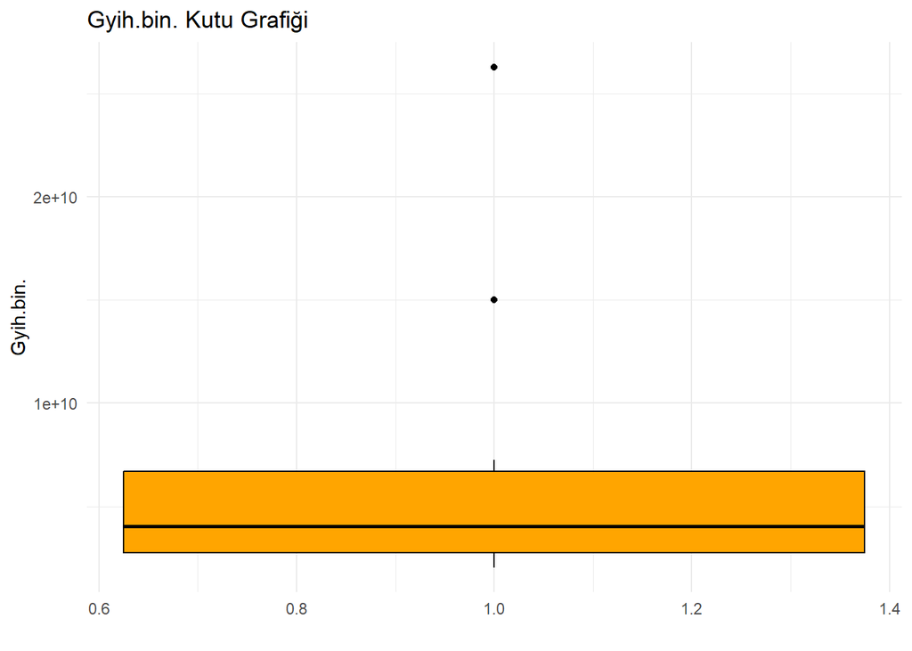

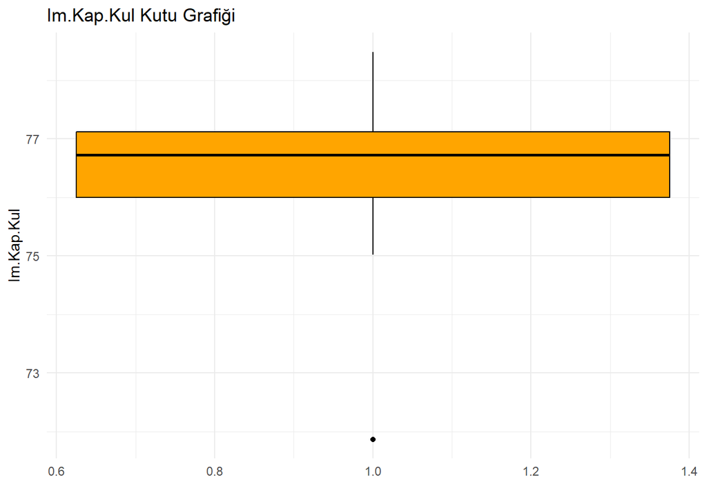

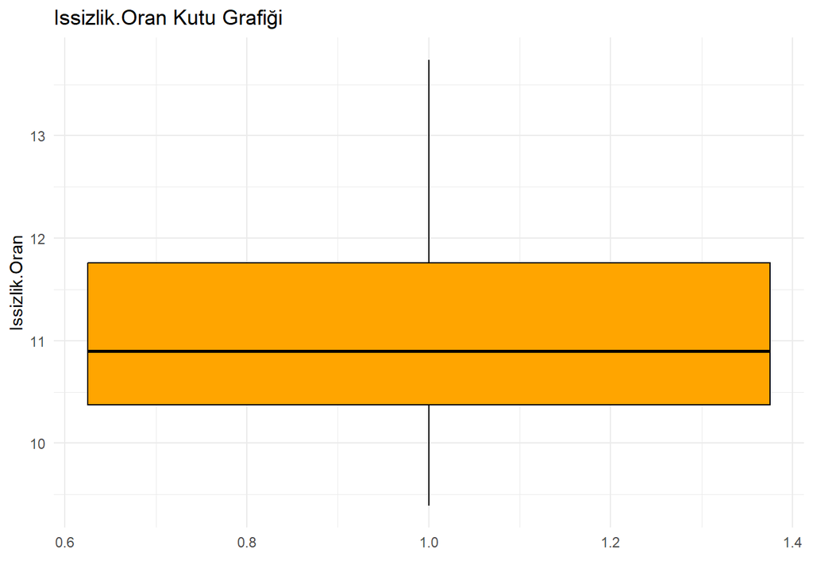

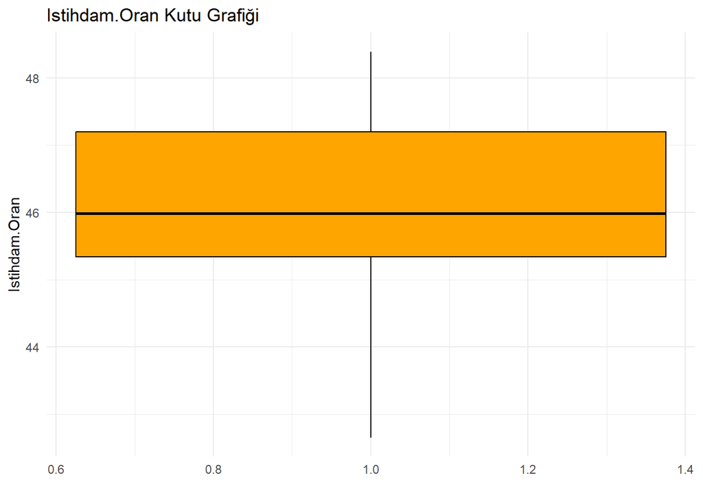

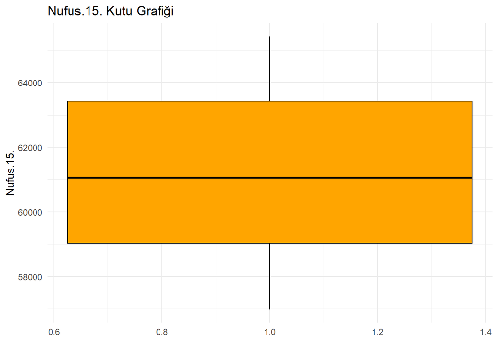

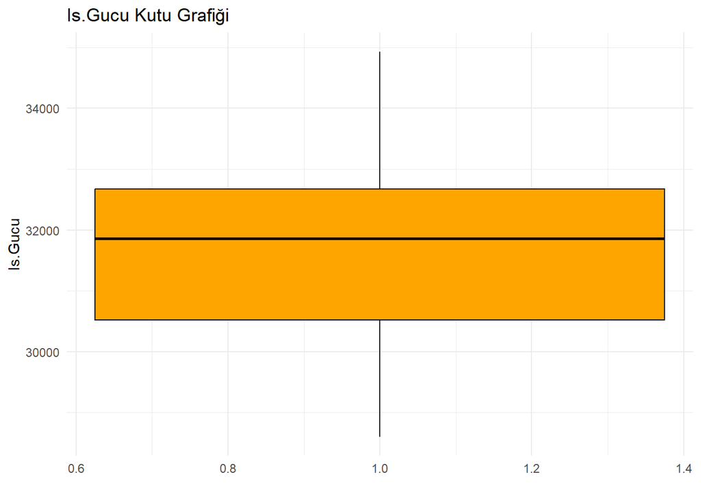

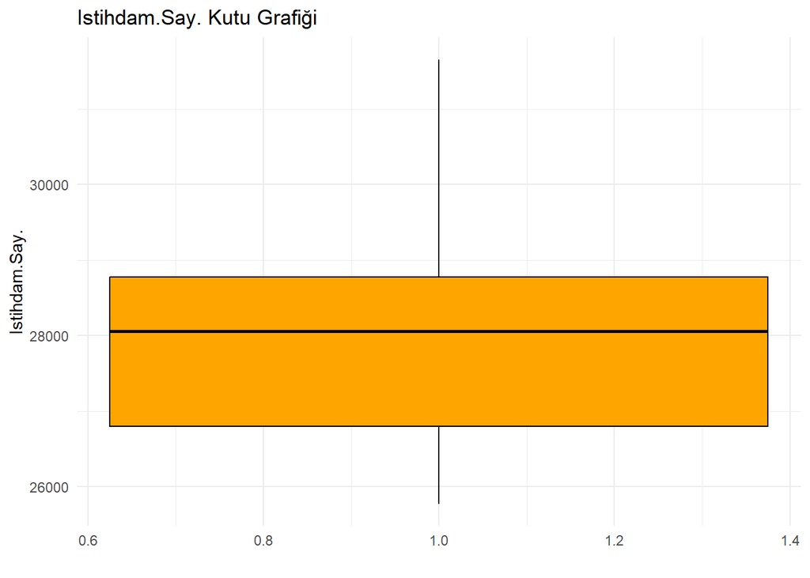

[5 more figures not shown]

```r
library(ggplot2)
numeric_columns <- names(data)[sapply(data, is.numeric)]
for (col in numeric_columns) {
  print(ggplot(data, aes_string(x = "1", y = col)) +
          geom_boxplot(fill = "orange", color = "black") +
          labs(title = paste(col, "Kutu Grafiği"), x = "", y = col) +
          theme_minimal())
}
```

*Kutu grafiklerinde dikkatimi çeken nokta istihdam oranı işsizlik gibi rakamların daha normal dağılırken altın,konut endeksi gibi finansal veriler tufe ve üfeyle benzer oranda dağılmakta ve aykırı değerlere sahip olduğunu göstermektedir.*

# Zaman serisi grafikleri

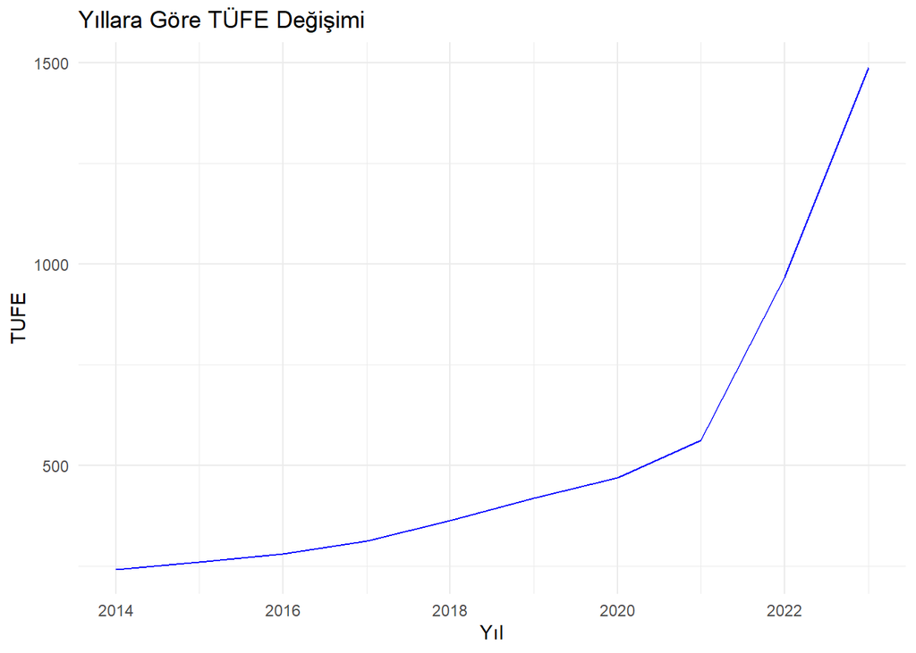

```r
ggplot(data, aes(x = as.numeric(Tarih))) +
  geom_line(aes(y = TUFE), color = "blue") +
  labs(title = "Yıllara Göre TÜFE Değişimi", x = "Yıl", y = "TUFE") +
  theme_minimal()
```

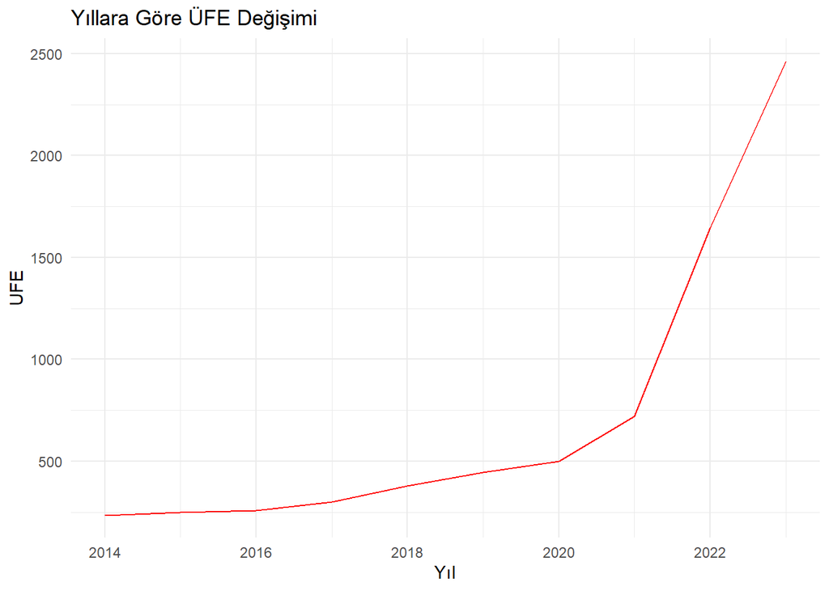

```r
ggplot(data, aes(x = as.numeric(Tarih))) +
  geom_line(aes(y = UFE), color = "red") +
  labs(title = "Yıllara Göre ÜFE Değişimi", x = "Yıl", y = "UFE") +
  theme_minimal()
```

*Zaman serisi analizimizde ise tüfe ve üfe oranlarının son yıllarda yüksek bir trende sahip olduğunu görmekteyiz

# Korelasyon

*Korelason matrisi ile bir çok niteliğimiz arasındaki ilişkiyi anlamak için kullanabiliriz*

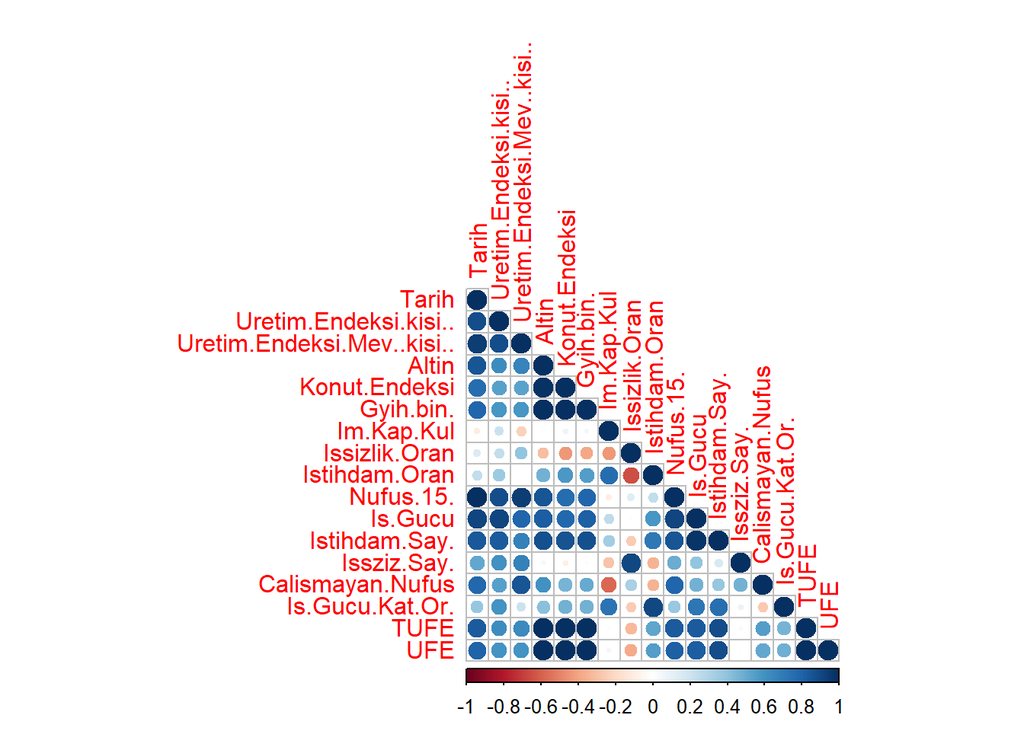

```r
# Gerekli kütüphaneleri yükleme
library(corrplot)
# Korelasyon matrisini hesapla
correlation_matrix <- cor(data)
# Korelasyon matrisini görselleştirme
corrplot(correlation_matrix, method = "circle" ,type = "lower")
```

**Korelasyon matrisine ilk bakışımızda pozitif ilişkilerin negatif ilişkilerden daha fazla olduğu göze çarpmaktadır.Tüfe ve üfe değeri zaman serisi görselinde sürekli ve hızlı artan bir eğimde olduğu göz önüne alınırsa bir çok niteliğide beraberinde arttırdığı yorumu yapılabilir**

```r
# Korelasyon matrisini hesapla
correlation_matrix <- cor(data)

# Korelasyon matrisini düzleştirme
flat_correlation <- as.data.frame(as.table(correlation_matrix))

# Pozitif en yüksek korelasyonları bulma (0.8'den büyük olanlar)
positive_max <- flat_correlation[flat_correlation$Freq > 0.95 & flat_correlation$Freq < 1, ]
positive_max
```

```
##              Var1          Var2      Freq
## 10      Nufus.15.         Tarih 0.9992233
## 56  Konut.Endeksi         Altin 0.9855957
## 57      Gyih.bin.         Altin 0.9930881
## 67           TUFE         Altin 0.9978743
## 68            UFE         Altin 0.9934202
## 72          Altin Konut.Endeksi 0.9855957
## 74      Gyih.bin. Konut.Endeksi 0.9974374
## 84           TUFE Konut.Endeksi 0.9912772
## 85            UFE Konut.Endeksi 0.9948497
## 89          Altin     Gyih.bin. 0.9930881
## 90  Konut.Endeksi     Gyih.bin. 0.9974374
## 101          TUFE     Gyih.bin. 0.9974499
## 102           UFE     Gyih.bin. 0.9960094
## 154         Tarih     Nufus.15. 0.9992233
## 182 Istihdam.Say.       Is.Gucu 0.9708615
## 198       Is.Gucu Istihdam.Say. 0.9708615
## 259         Altin          TUFE 0.9978743
## 260 Konut.Endeksi          TUFE 0.9912772
## 261     Gyih.bin.          TUFE 0.9974499
## 272           UFE          TUFE 0.9964023
## 276         Altin           UFE 0.9934202
## 277 Konut.Endeksi           UFE 0.9948497
## 278     Gyih.bin.           UFE 0.9960094
## 288          TUFE           UFE 0.9964023
```

*En yüksek ilişkilerin finansal veriler arasında olması işsizlik verilerinin daha ortalama seyrinde gittiğini ve trende göre geri kaldığını yorumlayabiliriz. Ayrıca TÜFE ve ÜFE deki artışın işssizlik rakamlarına yüksek bir katkısı olmadığı yorumlanabilir*

```r
# Negatif en yüksek korelasyonları bulma (-1'e en yakın olanlar)
negative_max <- flat_correlation[flat_correlation$Freq == min(flat_correlation$Freq) & flat_correlation$Freq > -1, ]
negative_max
```

```
##              Var1          Var2       Freq
## 128 Istihdam.Oran Issizlik.Oran -0.6494048
## 144 Issizlik.Oran Istihdam.Oran -0.6494048
```

*Negatif yönlü en güçlü işişkinin İstihdam orani ve İşsizlik oranı arasında olması oldukça mantıklı bir sonuçtur. İstihdam oranı arttıkça işsizlik oranının azalmas beklenen bir sonuçtur.*